# Homework 6

## Q4

Now let’s remove the seasonality and look at the two datasets jointly. For each dataset, find the annual average of the main data columns (`ppm`,`ph`) so you have a single average for each year. Join these two averaged data frames by year, then show a scatterplot of ocean acidity (Y) vs co2 concentration (X). Add a line of best fit through the data with error bands hidden.

Briefly comment on the plot, what do you notice? Does this plot agree with what you saw for previous questions?

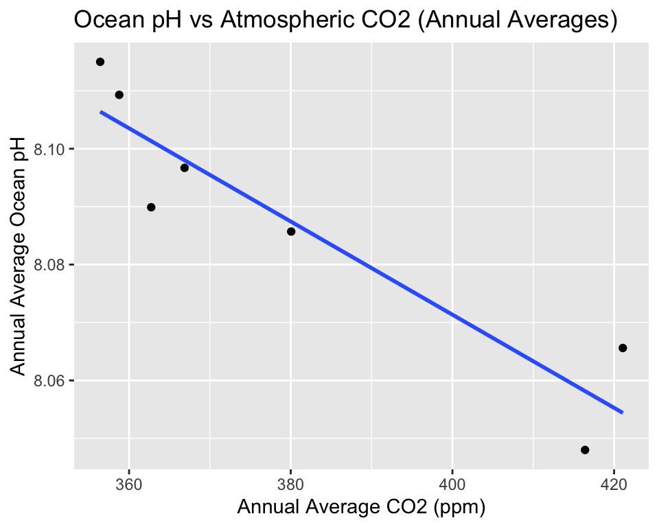

```r
# annual average co2 :

co2_annual = co2 %>%
  mutate(year = year(date)) %>%
  group_by(year) %>%
  summarise(mean_ppm = mean(ppm, na.rm=TRUE))


# annual average pH :

ph_annual = ph %>%
  mutate(year = year(date)) %>%
  group_by(year) %>%
  summarise(mean_ph = mean(ph, na.rm=TRUE))

# join both

combined_annual = inner_join(co2_annual, ph_annual, by = "year")

# scatter plot :

ggplot(combined_annual, aes(x = mean_ppm, y = mean_ph)) +
  geom_point() +
  geom_smooth(method = "lm", se = FALSE) +
  labs(x = "Annual Average CO2 (ppm)",
       y = "Annual Average Ocean pH",
       title = "Ocean pH vs Atmospheric CO2 (Annual Averages)")
```

```r
# The scatter plot shows us a clear negative correlation as co2 concentration increases, ocean pH decreases.
# this also matches the previous findings, the ocean absorbs more co2 as levels rise.
# the joint view removes the seasonal variability, showing us the link between increasing co2 and ocean acid over time.
```